# Homework 1

Alessandro Quattrociocchi - 1609286

### Part 1

#### 1.1 Data Presentation

The Roma car accidents dataset has nineteen observations of five variables as: the number of weeks the observations occurred, the day of the week, the observation time, the number of accidents, and a registration number.

```r
str(mydata)
```

```
## 'data.frame':    19 obs. of  5 variables:
##  $ week          : int  2 3 4 5 6 7 8 9 10 11 ...
##  $ weekday       : chr  "Saturday" "Saturday" "Saturday" "Saturday" ...
##  $ hour          : int  9 9 9 9 9 9 9 9 9 9 ...
##  $ car_accidents : int  3 2 4 1 4 8 4 8 3 5 ...
##  $ sign_up_number: int  104 104 104 104 104 104 104 104 104 104 ...
```

For the homework, we are interested only in the number of accidents, in fact the measurements are all performed in the same conditions of time and day of the week. We also know that our data are distributed according to a Poisson Model with $\lambda = 3.22$, this information will often come in handy later on. Below is a plot of the probability of a given number of car accidents occurring on a Saturday at 9:00 AM.

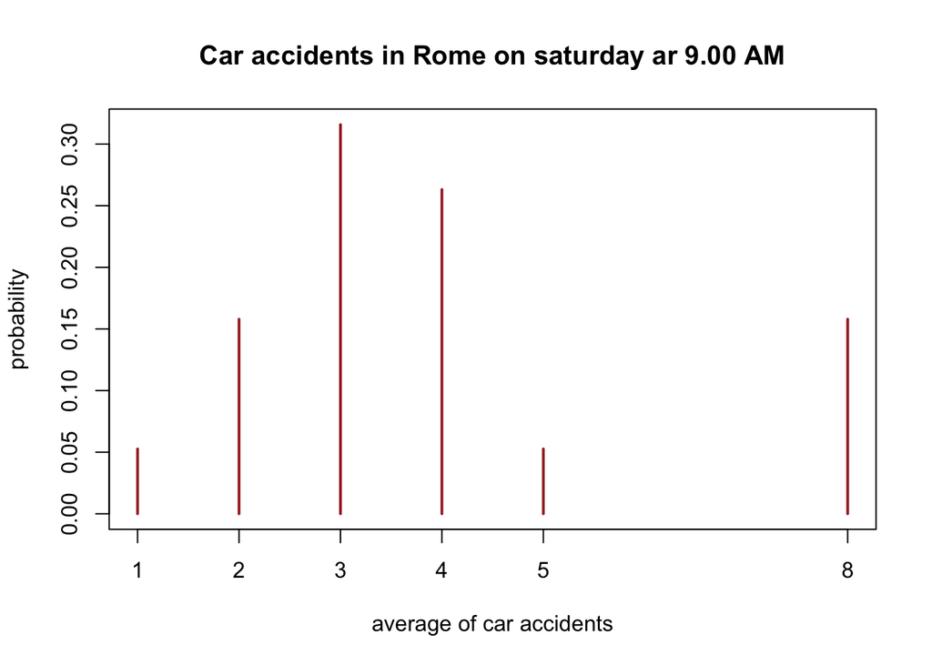

#### 1.2 Bayesian Ingredients for the Poisson Models

Assuming that our data are n observations from a Poisson distribution with parameter $\lambda = 3.22$, we can build a Poisson conjugate analysis. Our goal is to estimate the parameter that represents the average number of car accidents according to the observation contained in the dataset. Some theoretical results obtained by considering the **Poisson** distribution as the *likelihood* distribution and the **Gamma** distribution as the *prior* are reported below. The main reason is to find a re-parameterization that would help us to express in analytical form the posterior distribution and from that to extrapolate the new parameters for the inference. The following implementation takes into account that the sample is *iid*.

##### Main Inferential findings

$$\begin{align}
J(y,\theta) = f(y|\theta)\pi_{h}(\theta)
\end{align}$$
$$\begin{align}
\pi(\theta) = \frac{r^s}{\Gamma(s)}e^{-r\theta}\theta^{s-1}I_{(0,+\infty)}(\theta)
\end{align}$$
$$\begin{align}
Y_1,...,Y_n|\theta \sim f(y_1,...,y_n|\theta) = \prod_{i=1}^{n}{y_i|\theta} =
\prod_{i=1}^{n}\frac{{e^{-\theta}\theta^{y_i}}}{y_i!} \propto e^{-n \theta}\theta^{\sum_{i=1}^{n}y_i}
\end{align}$$
$$\begin{align}
\pi(\theta|y_1,...y_n) \propto \pi(\theta)L_Y(\theta) \propto e^{-r\theta}\theta^{s-1}e^{-n\theta}\theta^{ \sum_{i=1}^{n}-1}=
\propto e^{-\theta(r+n)}\theta^{s + \sum_{i=1}^{n}-1}
\end{align}$$

According to this calculation, we can reparametrize a gamma with the updated parameters:

$$\begin{equation}
r^* = r + n
\\
s^* = s + \sum_{i=1}^{n}y_i
\end{equation}$$

$$\begin{align}
\begin{cases}
E[\theta] = \frac{s}{r} = \mu
\\
Var[\theta] = \frac{s}{r^2} = \frac{\mu}{r}
\end{cases}
\end{align}$$

Below are reported three different gamma distributions to emphasize how different rate and shape of the curve generate different types of curves. In the next section, it will be explained with which criterion the parameters have been chosen.

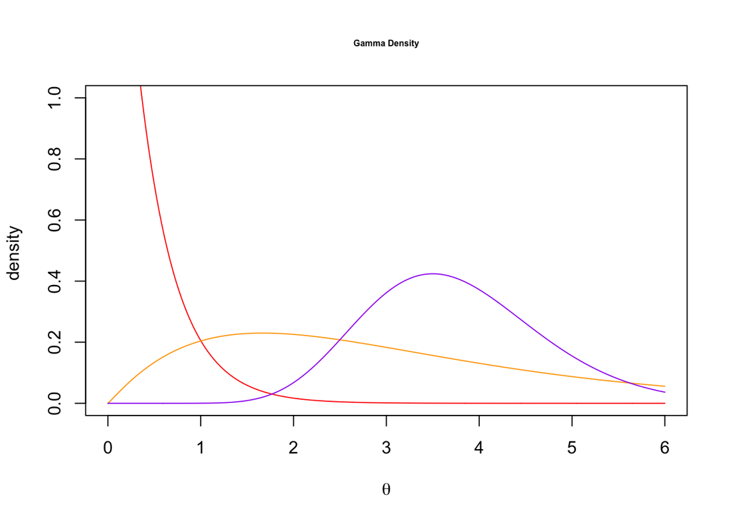

#### 1.3.a Parameters choises

For the choice of the parameters, we proceeded with different steps. The initial choice of parameters was random, as seen in the plot reported earlier. Later, however, it was decided to enhance the information we had on the distribution of our data and observations. For this reason on the one hand we chose a curve that, at least vaguely, recalled the trend of our data, but in the end, we selected the parameters using mean equal to the lambda of the Poisson equal to 3.22 and set a threshold on the variance equal to 5. The variance threshold was chosen in such a way that it could reflect how uncertain we were with respect to the known mean value of the distribution.

```r
r = 3.22/5
s = ((3.22)^2)/5

cat(mean(rgamma(1000000,rate=r,shape=s)),var(rgamma(1000000,rate=r,shape=s)))
```

```
## 3.224522 5.013559
```

```r
r_upd <- r+n
s_upd <- s+sum(y_obs)
posterior_mean = s_upd/r_upd
posterior_var  =  posterior_mean/r_upd

cat("posterior mean and variance: ",posterior_mean,posterior_var)
```

```
## posterior mean and variance:  3.872617 0.1971399
```

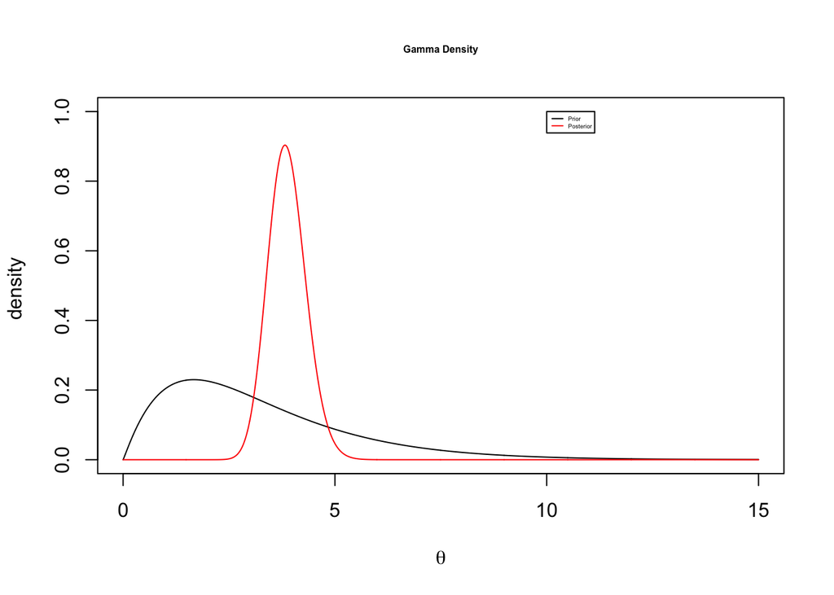

#### 1.3.b Posterior Uncertainty

For the posterior uncertainty, we can consider the variance as
$$\begin{align}
Var[\theta] = \frac{shape}{rate^2}
\end{align}$$

As we can see the value we found from the estimate is very close to the theoretical value obtained by exploiting the generation of **10000** samples from the gamma function and then calculated the variance. We can see that in solving the system had assigned a variance of five. After implementing the Bayesian framework we saw how the distribution is more concentrated around the mean value, with a net decrease in variance (about 96%).

```r
cat("Simulated Value",var(rgamma(10000, rate = r_upd, shape = s_upd)))
```

```
## Simulated Value 0.1908577
```

```r
posterior_variance <- s_upd/r_upd^2
cat("Value from the bayesian framework: ", posterior_variance)
```

```
## Value from the bayesian framework:  0.1971399
```

#### 1.3.c Intervals Estimations

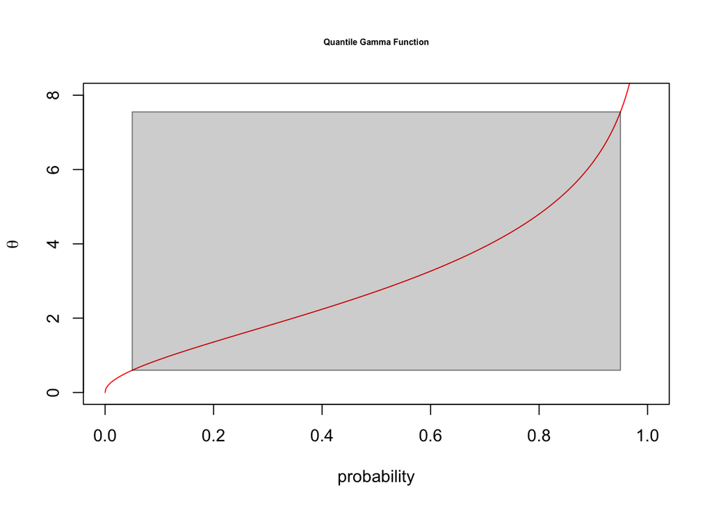

```r
lower_ci <- qgamma(c(0.05,0.95), rate = r, shape = s)[1]
upper_ci <- qgamma(c(0.05,0.95), rate = r, shape = s)[2]
curve(qgamma(x, rate = r, shape = s),from=0,to=1,ylim = c(0,8),xlab="probability",
      ylab =expression(theta),
      main = "Quantile Gamma Function",cex.main=0.5,1000,col="red")
rect(xleft  = 1-0.05, ybottom = lower_ci,
     xright = 0.05, ytop = upper_ci,
     border = rgb(0,0,0,.5), col = rgb(0,0,0,.2))
```

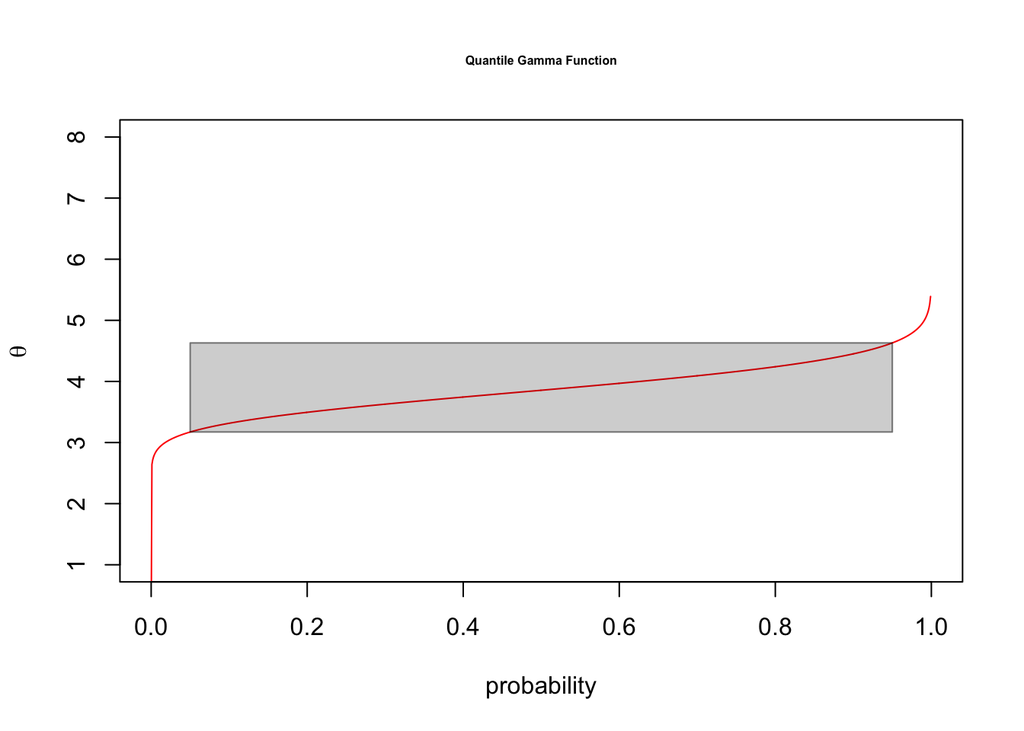

```r
lower_ci_upd <- qgamma(c(0.05,0.95), rate = r_upd, shape = s_upd)[1]
upper_ci_upd <- qgamma(c(0.05,0.95), rate = r_upd, shape = s_upd)[2]

curve(qgamma(x, rate = r_upd, shape = s_upd),from=0,to=1,ylim = c(1,8),xlab="probability",ylab =expression(theta),
      main = "Quantile Gamma Function",cex.main=0.5,1000,col="red")
rect(xleft  = 1-0.05, ybottom = lower_ci_upd,
     xright = 0.05, ytop = upper_ci_upd,
     border = rgb(0,0,0,.5), col = rgb(0,0,0,.2))
```

```r
cat("Credible Intervals: ",qgamma(c(0.05,0.95), rate = r_upd, shape = s_upd))
```

```
## Credible Intervals:  3.172359 4.630715
```

#### 1.3.d Posterior Predictive Distribution

Let us suppose that we have observed the data and using the updating formula we used to reach the new parameters. Now, if we want to predict a new value according to the estimation, we can consider our previous posterior as the new prior and from them derive the new posterior.

According to this:

$$\begin{align}
p(y_{new}|\theta) = \int_{\Theta} f(y|\theta)= \int_{0}^{+ \infty}
\frac{e^{-\theta}\theta^{y}}{y!}
\frac{r^s}{\Gamma(s)}
e^{-r\theta}\theta^{s-1}=
\frac{r^s}{\Gamma(s)}\frac{1}{y!} \int_{0}^{+\infty}e^{(r+1)\theta}\theta^{s+y-1} =
\frac{r^s}{\Gamma(s)}\frac{1}{y!}\frac{\Gamma(s+y)}{(r+1)^{s+y}} =
\end{align}$$

$$\begin{align}
=\frac{\Gamma(s+y)}{\Gamma(s)}\frac{1}{y!}\bigg(\frac{r}{r+1}\bigg)^{s}\bigg(\frac{1}{r+1}\bigg)^y
\end{align}$$

$$\begin{align}
\begin{cases}
E[\theta] = \frac{pr}{1-p}
\\
Var[\theta] = \frac{pr}{(1-p)^2}
\end{cases}
\end{align}$$

Suppose then that we want to generate 500 new observations according to the parameter estimation. This is a comparison between the negative binomial (predictive) and the Poisson according to the estimated rate.

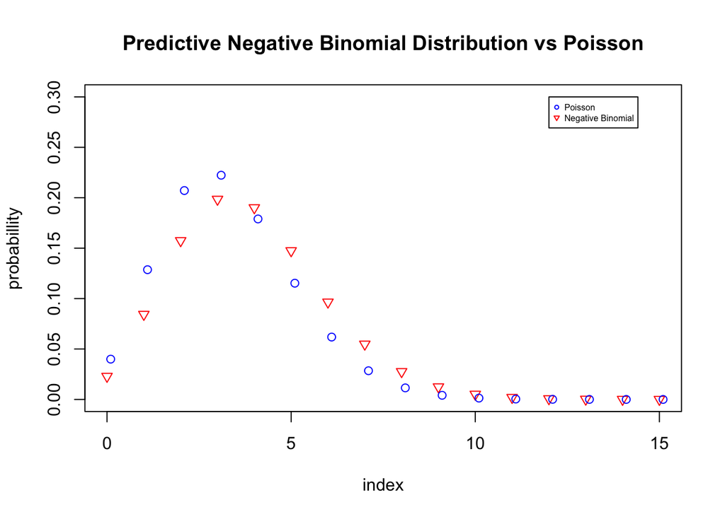

## Part 2: Bulbs lifetime estimation

This dataset is a vector composed of twenty ascendingly ordered observations of the average lifetime of some innovative bulbs. As we can see from the plot, the sample trend presents an exponential behavior.

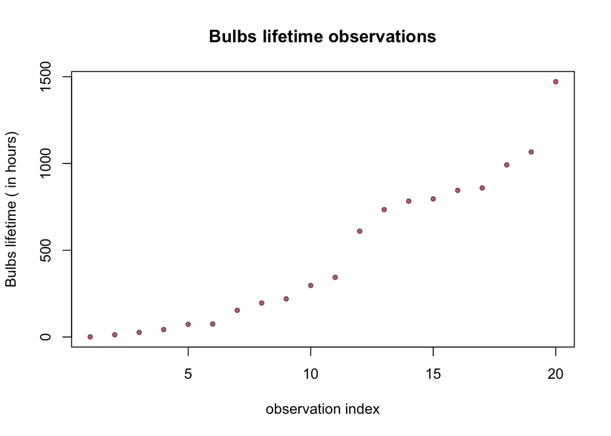

#### 2.1 Ingredients for the Bayesian Conjugate Analysis for an Exponential Distribution

Assuming that our observations are distributed as an exponential, also in this case a gamma(shape, rate) distribution is the correct prior.

$$\begin{align}
f(x,\theta) = \theta e^{-\theta x} I_{[0,\infty]}
\end{align}$$
$$\begin{align}
L_y = \prod_{i=1}^{n} \theta e^{-\theta y_i} = \theta^{n}e^{-\theta \sum_{1}^{n}y_i}
\end{align}$$

$$\begin{align}
\boxed{\pi(\theta|y_1,...,y_n) \propto \theta^{(s+n-1)}e^{-\theta(r+\sum_{i=1}^{n}y_i)}}
\end{align}$$

$$\begin{align}
\begin{cases}
r^* = r + \sum_{i+1}^{n}y_i
\\
s^* = s + n
\end{cases}
\end{align}$$

#### 2.2 Conjugate prior distribution with mean = 0.003 and sd = 0.00173

$$\begin{align}
\begin{cases}
E[\theta] = \frac{s}{r} = 0.003
\\
Var[\theta] = \frac{s}{r^2} = (0.00173)^2
\end{cases}
\longrightarrow
\begin{cases}
r = 1002.37
\\
s = 3.01
\end{cases}
\end{align}$$

Taking advantage of LLN can be verified that the mean and the variance are the one selected according to the paramters rate and shape.

```r
cat(mean(rgamma(100000,rate=r,shape=s)),sd(rgamma(100000,rate=r,shape=s)))
```

```
## 0.002999295 0.001729827
```

#### 3. Argue why this choise you are providing only a vague prior opinion on the average lifetime of the bulb.

Fixing the value of the average and the variance by solving the above system, we can fix, but only in a vague way, the value of the average lifetime of the bulbs. In fact, moving the shape and the rate we are going to act on the values of the average and the variance of our distribution. We also know that from the re-parameterization, we have obtained a new gamma distribution (posterior) with updated shape and rate values. These updated values are calculated taking into account the observations, which is why they are influenced by the data. In this case, the rate will depend on the sum of observations while the shape will depend on the number of observations. So, we can set possible values of mean and variance depending on our a prior beliefs about the distribution but after observing the data and calculating our posterior we can see if it is in line with that values previously set.

#### 4. Show that this setup fits into the framework of the conjugate Bayesian Analysis

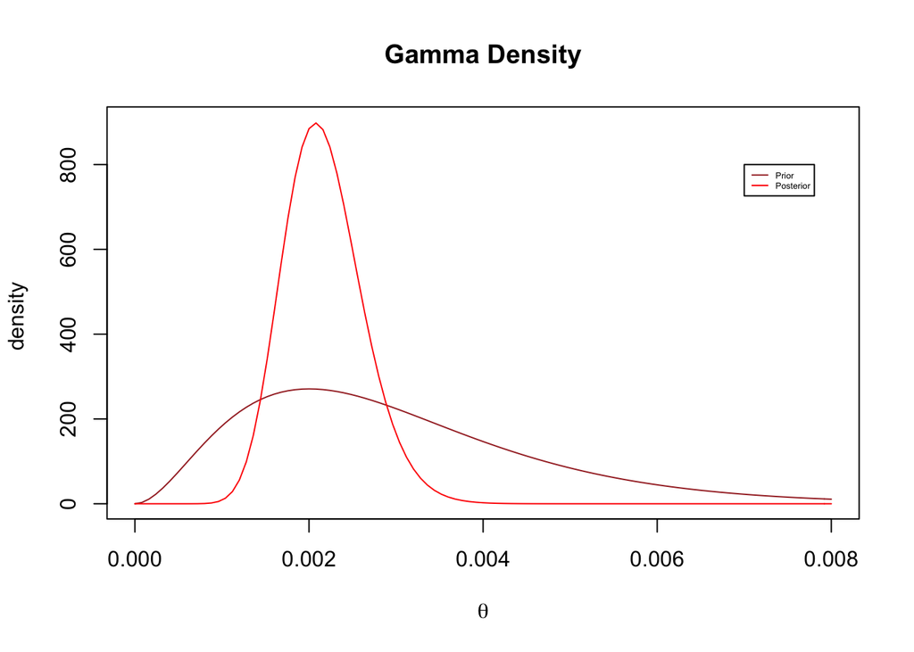

```r
par(mfrow=c(1,1))
curve(dgamma(x,rate=r,shape=s),xlim = c(0,.008),ylim=c(0,900),xlab=expression(theta)
      ,ylab = "density ",main = "Gamma Density" , col="brown")
curve(dgamma(x,rate=r_upd,shape=s_upd),xlim = c(0,.008),xlab=expression(theta),
      col="red", add = TRUE)
legend(0.0070, 800, legend=c("Prior","Posterior"),
       col=c("brown","red"), lty=1:1, cex=0.4)
```

```r
#posterior mean
posterior_mean_for_time = round(1/(s_upd/(r_upd)), digits = 3)
cat("Posterior mean", posterior_mean_for_time)
```

```
## Posterior mean 460.787
```

#### 5. Argue why learn something on theta can be used also for $1/ \theta$

Our goal was to estimate the lifetime of the bulbs described by the exponential distribution. We also know that the expected value of an exponential distribution is equal to $1/\theta$, so through the distribution we estimated the parameter and usign the parameter the expected value of the distribution.

$$\begin{align}
p(E[\frac{1}{\theta}|y_1,...,y_n]) = \frac{bE[\frac{1}{\theta}]+n\bar{y}}{b+n}
\end{align}$$

```r
library(invgamma)
y_bar <- mean(obs)
n <- length(obs)
bma <- (s*dinvgamma(500, shape=s, rate=r) +n*y_bar)/(s+n)
p <- 1- pinvgamma(bma, shape = s_upd, rate = r_upd)
cat("Average Lifetime Probability > 500: ", p)
```

```
## Average Lifetime Probability > 500:  0.7100106
```